# Tuning SNIC Compactness

## Why compactness matters

The compactness parameter in `snic()` balances spectral contrast and spatial coherence. Very low values let clusters follow the image gradients closely, while higher values favor more rounded superpixels that can cross faint edges. Exploring a range of compactness values on a representative tile helps decide what works best for a given task.

## Preparing a demo scene

```r
data_dir <- system.file("S2-20LMR", package = "snic", mustWork = TRUE)
band_names <- c(
  "S2_20LMR_B02_20220630.tif",
  "S2_20LMR_B04_20220630.tif",
  "S2_20LMR_B08_20220630.tif",
  "S2_20LMR_B12_20220630.tif"
)
s2 <- rast(file.path(data_dir, band_names))
s2_demo <- aggregate(s2, fact = 8)
```

The tile preserves the multi-band structure of the original Sentinel-2 subset while keeping the vignette fast to knit.

Seeds are generated once so that only compactness changes between runs.

```r
spacing <- 28L
seeds <- snic_grid_rect(s2_demo, spacing = spacing)
length(seeds[, 1])
```

```
#> [1] 12
```

## Comparing compactness values

```r
compactness_values <- c(0.05, 0.5, 2)
segments <- lapply(
  compactness_values,
  function(cmp) {
    snic(s2_demo, seeds = seeds, compactness = cmp)
  }
)
names(segments) <- paste0("c=", compactness_values)
segments
```

```
#> $`c=0.05`
#> class       : SpatRaster
#> size        : 96, 128, 1  (nrow, ncol, nlyr)
#> resolution  : 160, 160  (x, y)
#> extent      : 429960, 450440, 9046000, 9061360  (xmin, xmax, ymin, ymax)
#> coord. ref. : WGS 84 / UTM zone 20S (EPSG:32720)
#> source(s)   : memory
#> name        : snic
#> min value   :    1
#> max value   :   12
#>
#> $`c=0.5`
#> class       : SpatRaster
#> size        : 96, 128, 1  (nrow, ncol, nlyr)
#> resolution  : 160, 160  (x, y)
#> extent      : 429960, 450440, 9046000, 9061360  (xmin, xmax, ymin, ymax)
#> coord. ref. : WGS 84 / UTM zone 20S (EPSG:32720)
#> source(s)   : memory
#> name        : snic
#> min value   :    1
#> max value   :   12
#>
#> $`c=2`
#> class       : SpatRaster
#> size        : 96, 128, 1  (nrow, ncol, nlyr)
#> resolution  : 160, 160  (x, y)
#> extent      : 429960, 450440, 9046000, 9061360  (xmin, xmax, ymin, ymax)
#> coord. ref. : WGS 84 / UTM zone 20S (EPSG:32720)
#> source(s)   : memory
#> name        : snic
#> min value   :    1
#> max value   :   12
```

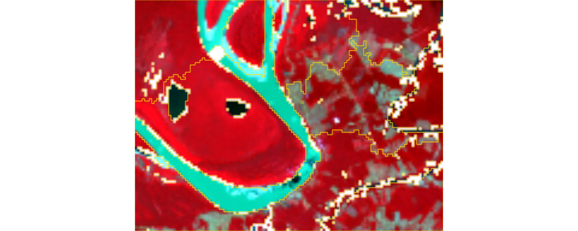

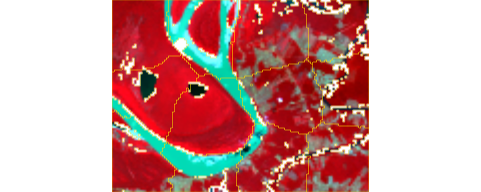

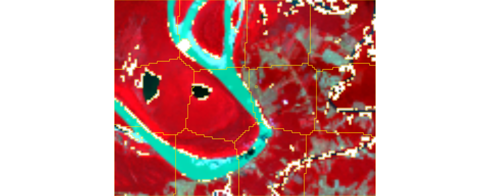

```r
oldpar <- par(mfrow = c(1, 3), mar = c(2.5, 2.5, 2, 0.5))
on.exit(par(oldpar), add = TRUE)
for (i in seq_along(segments)) {
  snic_plot(
    s2_demo,
    r = 3, g = 2, b = 1,
    stretch = "lin",
    seg = segments[[i]],
    seg_plot_args = list(border = "#FFD700", col = NA, lwd = 0.6),
    main = names(segments)[[i]]
  )
}
```

## Choosing a practical value

There is no universally optimal compactness. A good workflow is to:

1. Inspect representative regions with a grid of compactness values (for instance `seq(0.05, 2, length.out = 6)`).
2. Note where edges become too ragged or, conversely, where distinct objects are merged.
3. Select the smallest compactness that keeps segments stable across the features of interest.

Once the parameter is selected for a study area, keep both `seeds` and `compactness` fixed to ensure results are reproducible. Use additional vignettes to explore how seed spacing and layout complement that choice.